# Getting high-frequency borehole strain data

Andrew J Barbour

2023-10-06

There are multiple ways to assemble high-frequency borehole strainmeter (BSM) data from the Network of the Americas (NOTA) network. Here I review the capabilities provided by functions in the `strain` package (https://github.com/abarbour/strain), and show an alternative method for accessing them via the IRIS-DMC timeseries webservice (http://service.iris.edu/irisws/timeseries/1/)

## IRIS webservices

We’ll start with a method that doesn’t depend on the `strain` package: IRIS-DMC, which offers strain timeseries through their webservices. To download 1 Hz data for a single channel (e.g., channel 4), the URL would look something like this: (https://service.iris.edu/irisws/timeseries/1/query?net=PB&sta=B004&loc=T0&cha=LS4&start=2009-08-03T17:40:00&dur=2700&format=plot) where we’ve set the format to produce a plot in the browser[^1]. This shows teleseismic waves in Cascadia from the 2009 M6.9 Canal de Ballenas earthquake in the Gulf of Mexico. To download this we have to save a file locally and load in the table of values. The option `format=ascii` gives a table of timestamps and values, but my preference is to use `format=geocsv` which contains more header information. One approach is:

```r
library(readr)
ch4_url <- paste('https://service.iris.edu/irisws/timeseries/1/query?net=PB',
                 'sta=B004',
                 'cha=LS4',
                 'loc=T0',
                 'start=2009-08-03T17:40:00',
                 'duration=3600',
                 'format=geocsv', sep="&")
ch4_dest <- tempfile(fileext='.csv')

# download and read-in csv
download.file(ch4_url, destfile=ch4_dest)
ch4 <- readr::read_csv(ch4_dest, comment = '#')
```

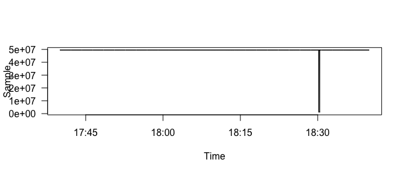

```r
# plot using built-in method of two-column posix-time data.frame
plot(ch4, type='l')
```

Note the large spike which obscures the plot axis: this is because a value of `999999` is inserted at times of missing data. This can be fixed easily, and we’ll remove the mean to have more sensible plot limits:

```r
remove_bad <- function(x) ifelse(x==999999,NA,x)

library(dplyr)
```

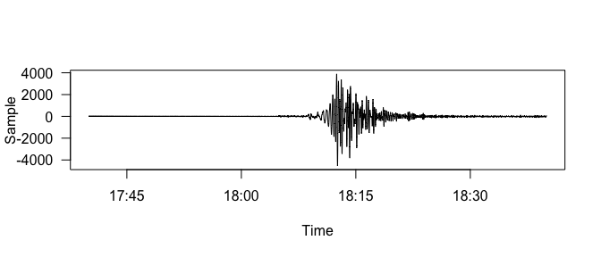

```r
ch4 <- dplyr::mutate(ch4,
                     Sample = remove_bad(Sample),
                     Sample = Sample - mean(Sample, na.rm=TRUE))

plot(ch4, type='l')
```

The record plotted above is in raw counts and does not represent linear, uniaxial strain. To convert to strain we need to linearize with a very straightforward equation that takes into account the known capacitance gap distance and the analog-to-digital digitization scale:

```r
raw2lin <- function(g, station){
  diam <- 87e-3 # 87 mm
  gap <- 100e-6 # 100 micron for some, 200 micron for others
  # https://github.com/abarbour/pborepo/blob/master/data/gen/bsm_gaps
  if (!missing(station)){
    if (station %in% c('B001','B003','B004','B005','B006','B007','B009',
                     'B010','B011','B012','B018',
                     'B022','B024',
                     'B035',
                     'B081','B082','B086','B087')){
      gap <- 2 * gap
    }
  } else {
    warning('no station given; capacitance gap assumed to be {',
            gap*1e6,
            '} microns',
            call. = FALSE, immediate. = FALSE)
  }
  G <- g / 1e8
  (gap / diam) * G / (1 - G)
}
raw2lin(1)
raw2lin(1,'B001')
```

[output not shown]

```
#> [1] 2.298851e-11
```

Applying this to the raw strain timeseries, scaling to nanostrain (1 part-per-billion), and subtracting the first value gives the result we want:

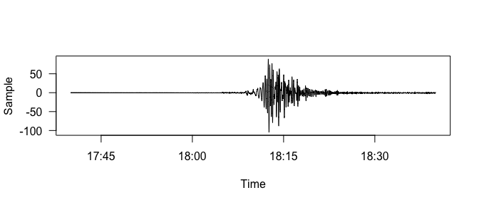

```r
# linearize and convert to nanostrain, make relative to first observation
ch4 <- dplyr::mutate(ch4,
                     Sample = raw2lin(Sample, station='B004') * 1e9,
                     Sample = Sample - Sample[1])
plot(ch4, type='l')
```

Unfortunately, wildcards do not work in the IRIS-webservices schema. To get the full record at station B004 – all four gauges – we have to repeat this procedure four times, and combine the records.

```r
get_linstrain_iris <- function(Station, Channel, Start, Duration, samp=NULL, clean=TRUE){
  require(dplyr)
  require(readr)
  Samp <- match.arg(samp, c('1','20'))
  Code <- ifelse(Samp=='1','L','B')
  stopifnot(Channel %in% c(1,2,3,4))
  ChanCode <- sprintf("%sS%s",Code,Channel)

  Start <- strftime(Start, "%FT%T")

  ch_url <- paste('https://service.iris.edu/irisws/timeseries/1/query?net=PB',
                  sprintf('sta=%s', Station),
                  sprintf('cha=%s', ChanCode),
                 'loc=T0',
                 sprintf('start=%s', Start),
                 sprintf('duration=%s', Duration),
                 'format=geocsv', sep="&")
  message(ch_url)
  ch_dest <- tempfile(fileext='.csv')

  download.file(ch_url, destfile=ch_dest)
  ch <- readr::read_csv(ch_dest, comment = '#')
  if (clean){
    ch <- dplyr::mutate(ch,
                        Sample = remove_bad(Sample),
                        Sample = Sample - mean(Sample, na.rm=TRUE))
  }
  ch <- dplyr::mutate(ch,
                       Sample = raw2lin(Sample, station=Station) * 1e9,
                       Sample = Sample - Sample[1])
  return(ch)
}
st <- '2009-08-03 17:40:00'
ch4alt <- get_linstrain_iris('B004', 4, Start=st, Duration=3600)
```

```
#> https://service.iris.edu/irisws/timeseries/1/query?net=PB&sta=B004&cha=LS4&loc=T0&start=2009-08-03T17:40:00&duration=3600&format=geocsv
#>
```

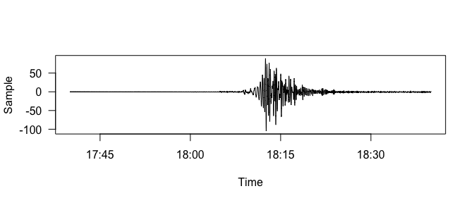

```r
plot(ch4alt, type='l')
```

```r
all.equal(ch4, ch4alt)
```

```
#> [1] TRUE
```

Now we can get the other channels,

```r
ch1alt <- get_linstrain_iris('B004', 1, Start=st, Duration=3600)
```

```
#> https://service.iris.edu/irisws/timeseries/1/query?net=PB&sta=B004&cha=LS1&loc=T0&start=2009-08-03T17:40:00&duration=3600&format=geocsv
#>
```

```r
ch2alt <- get_linstrain_iris('B004', 2, Start=st, Duration=3600)
```

```
#> https://service.iris.edu/irisws/timeseries/1/query?net=PB&sta=B004&cha=LS2&loc=T0&start=2009-08-03T17:40:00&duration=3600&format=geocsv
```

```r
ch3alt <- get_linstrain_iris('B004', 3, Start=st, Duration=3600)
```

```
#> https://service.iris.edu/irisws/timeseries/1/query?net=PB&sta=B004&cha=LS3&loc=T0&start=2009-08-03T17:40:00&duration=3600&format=geocsv
```

make a function to co-register the observation times,

```r
library(zoo)
to_ts <- function(d, ref.time, Hz=1){
  if (missing(ref.time)){
    ref.time <- d$Time[1]
  }
  stref <- as.POSIXct(ref.time)
  # calculate index of seconds relative to reference time
  y <- dplyr::mutate(d, Rel.sec = as.numeric(difftime(Time, stref, units = 'secs')))
  # build dummy time index to ensure completeness (e.g., if there are gaps)
  tfull <- data.frame(Rel.sec=seq(from=min(y$Rel.sec), to=max(y$Rel.sec), by=1/Hz))
  # join against dummy time index (fills with NA if missing)
  yfull <- dplyr::left_join(tfull, y, by='Rel.sec')
  z <- zoo::zoo(x=yfull$Sample, order.by = yfull$Rel.sec, frequency = Hz)
  return(z)
}
```

and assemble the final product

```r
stp <- as.POSIXct(st) + 5 # add an arbitrary offset to illustrate alignment
Ch1 <- to_ts(ch1alt, ref.time=stp)
Ch2 <- to_ts(ch2alt, ref.time=stp)
Ch3 <- to_ts(ch3alt, ref.time=stp)
Ch4 <- to_ts(ch4alt, ref.time=stp)

B <- zoo::merge.zoo(Ch1, Ch2, Ch3, Ch4, all=TRUE)
head(B)
```

```
#>           Ch1         Ch2        Ch3         Ch4
#> -5 0.00000000  0.00000000 0.00000000  0.00000000
#> -4 0.06896559 -0.02298849 0.00000000  0.04597703
#> -3 0.02298853  0.09195398 0.00000000  0.00000000
#> -2 0.04597706  0.02298850 0.02298849  0.04597703
#> -1 0.00000000  0.06896549 0.04597698 -0.02298851
#> 0  0.00000000  0.16091948 0.04597698 -0.02298851
```

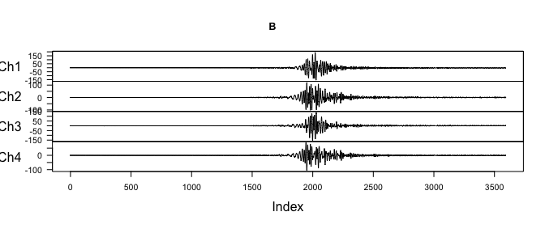

```r
plot(B)
```

```r
Bdf <- zoo::fortify.zoo(B, names='Rel.sec')
head(Bdf)
```

```
#>   Rel.sec        Ch1         Ch2        Ch3         Ch4
#> 1      -5 0.00000000  0.00000000 0.00000000  0.00000000
#> 2      -4 0.06896559 -0.02298849 0.00000000  0.04597703
#> 3      -3 0.02298853  0.09195398 0.00000000  0.00000000
#> 4      -2 0.04597706  0.02298850 0.02298849  0.04597703
#> 5      -1 0.00000000  0.06896549 0.04597698 -0.02298851
#> 6       0 0.00000000  0.16091948 0.04597698 -0.02298851
```

Now that the four channels are assembled, we can do things like calculate the RMS strain

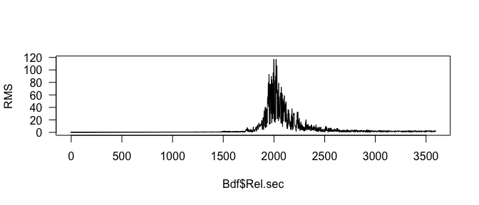

```r
Ch <- as.matrix(dplyr::select(Bdf, Ch1:Ch4))
RMS <- sqrt(rowMeans(Ch * Ch, na.rm = TRUE))
plot(Bdf$Rel.sec, RMS, type='l')
```

or apply a tidal calibration matrix

```r
# Isotropic calibration matrix
# see http://bsm.unavco.org/bsm/level2/B004/B004.README.txt
E.iso <- rbind(
  c(0.2967, 0.5185, 0.2958, 0.2222),
  c(-0.2887, 0.2983, 0.1688, -0.1784),
  c(-0.2660, -0.2196, 0.3531, 0.1325)
)
```

to transform the four gauge records into tensor strain combinations:

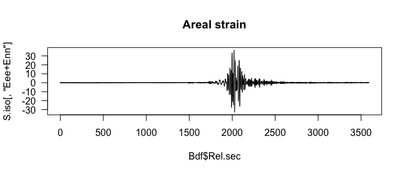

```r
S.iso <- Ch %*% t(E.iso)
colnames(S.iso) <- c('Eee+Enn','Eee-Enn','2Een')

plot(Bdf$Rel.sec, S.iso[,'Eee+Enn'], type='l', main='Areal strain')
```

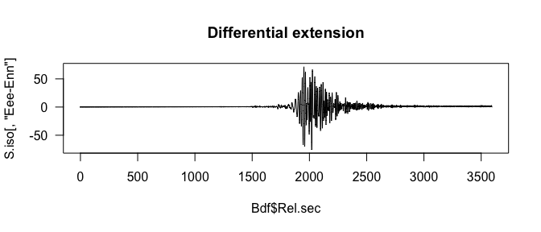

```r
plot(Bdf$Rel.sec, S.iso[,'Eee-Enn'], type='l', main='Differential extension')
```

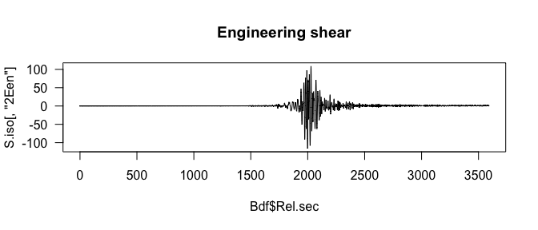

```r
plot(Bdf$Rel.sec, S.iso[,'2Een'], type='l', main='Engineering shear')
```

and to uniaxial strain components:

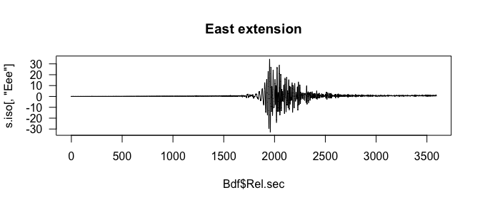

```r
e.iso <- rbind(
  c(1/2,1/2,0),
  c(1/2,-1/2,0),
  c(0,0,1/2)
)
s.iso <- S.iso %*% e.iso
colnames(s.iso) <- c('Eee','Enn','Een')

plot(Bdf$Rel.sec, s.iso[,'Eee'], type='l', main='East extension')
```

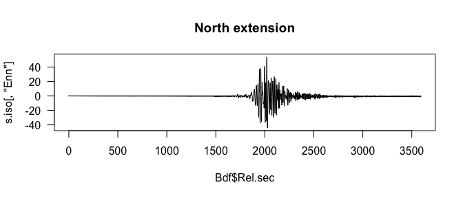

```r
plot(Bdf$Rel.sec, s.iso[,'Enn'], type='l', main='North extension')
```

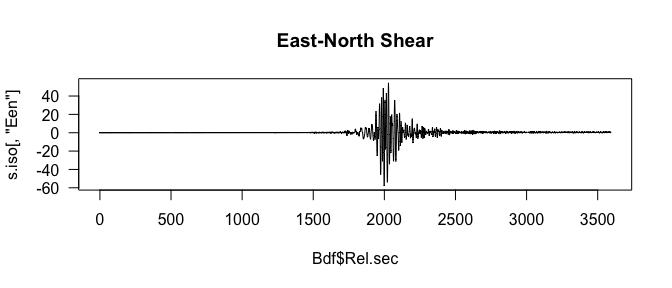

```r
plot(Bdf$Rel.sec, s.iso[,'Een'], type='l', main='East-North Shear')
```

## R package `strain`

The `strain` package has additional capabilities to assemble high-frequency strain data. Being a set of development codes, however, the code is not ready to be published on CRAN (https://cran.r-project.org/); hence, it must installed with either the `remotes` package:

```r
library(remotes)
remotes::install_github('abarbour/strain')
```

or by downloading the repository and installing with R built-in command line tools, e.g. `R CMD INSTALL strain.tar.gz`.

Then we can load the package and use its functionality:

```r
library(strain)
```

The main function is `hfbsm`, which calls build in scripts in the `inst/hfbsm/` directory (see https://github.com/abarbour/strain/tree/master/inst/hfbsm). Specifically, it calls the csh script `inst/hfbsm/hfbsm` which itself downloads the necessary raw data from the daily archives, and then calls `inst/hfbsm/bottlefile_merge.py` and `inst/hfbsm/bottlefile.py` sequentially. After the raw strains are assembled they are linearized in the same way before. This approach has the benefit of needing only a single command to get the data in question:

```r
res <- strain::hfbsm(sta = 'B004',
                     year=strftime(st, '%Y'),
                     jday=strftime(st, '%j'), # Julian day
                     st=strftime(st, '%T'), # h:m:s
                     duration=3000, sampling = 1)
```

[output not shown]

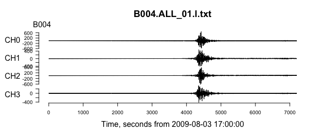

```r
dat <- strain::load_hfbsm(res)
plot(dat)
```

Note that because of the way the files are structured, the start of the data will not be exactly the start time requested. Additional processing may be needed to get the desired data window. Also note the result of `load_hfbsm` will be an object of class `hfbsm` which is a list containing the timeseries and timestamps, and other metadata

```r
class(dat)
```

```
#> [1] "hfbsm" "lin"
```

```r
str(dat,2)
```

```
#> List of 3
#>  $ srcdat  : Time-Series [1:7200, 1:4] from 1 to 7200: 0 -0.083 0.581 0.249 -0.332 ...
#>   ..- attr(*, "dimnames")=List of 2
#>  $ Datetime: POSIXct[1:7200], format: "2009-08-03 17:00:00" "2009-08-03 17:00:01" ...
#>  $ RelInd  : num [1:7200] 1 2 3 4 5 6 7 8 9 10 ...
#>  - attr(*, "sta4")= chr "B004"
#>  - attr(*, "file")= chr "B004.ALL_01.l.txt"
#>  - attr(*, "frequency")= num 1
#>  - attr(*, "cmd")= chr "/Users/abarbour-local/src/R/PACKAGES/strain/hfbsm/hfbsm B004 hokofallsbwa2005 2009 215 '17:40:00' 2009 215 '18:"| __truncated__
#>  - attr(*, "class")= chr [1:2] "hfbsm" "lin"
```

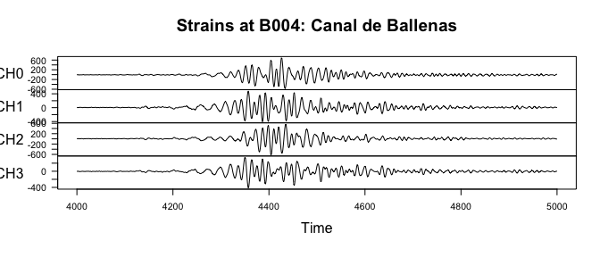

```r
# timeseries data are in 'srcdat' and can be easily windowed:
plot(window(dat[['srcdat']], 4000, 5000), main='Strains at B004: Canal de Ballenas')
```

The same scripts work on the command line; see `inst/hfbsm/01.test`.

[^1]: Had we set `cha=BS4` we would’ve gotten 20 Hz data, the highest sampling rate available.